# Full SEM Specification

## 4.1 Identification: structural model

Identification is also necessary for the structural component of SEM. Kenny outlines three rules that must be met in order to determine the identification of the structural model:

1. The number of estimated regression paths and correlations among exogenous variables and disturbances must not exceed the number of unique covariances among the constructs (i.e., the off-diagonal cells in the covariance matrix). That is:

$$k(k-1)/2 \geq p + \#r_{exo} + \#r_{dist} + \#r_{exo\&dist}$$
where…

$k$ = the number of constructs in the structural model $p$ = the number of (regression) paths

$\#r_{exo}$ = the number of correlations between exogenous variables

$\#r_{dist}$ = the number of correlations between disturbances

$\#r_{exo\&dist}$ = the number of correlations between exogenous variables and disturbances

What are the values of *k*, *p*, *#r<sub>exo</sub>*, *#r<sub>dist</sub>*, and *#r<sub>exo&dist</sub>* in the following models? Which models satisfy the above rule?

Figure 10.1b

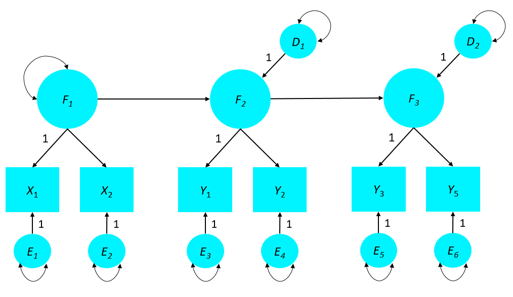

Figure 10.6

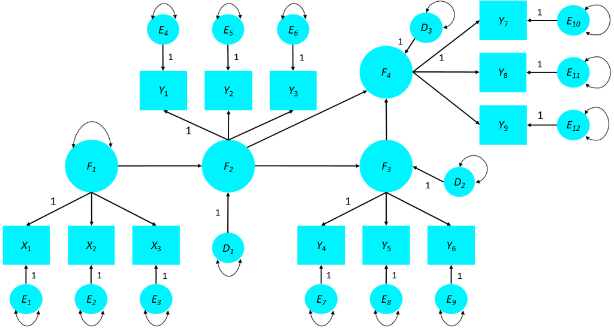

(for answers, click on “Code”) →

```r
#10.1b: 21 variances/covariances - 14 free parameters = 7 df; k = 3, p = 2, #r's all equal 0.)

#10.6: 78 variances/covariances - 28 free parameters = 50 df; k = 4, p = 4, #r's all equal 0.)
```

2. Only one of the following four possible situations can be true for any pair of constructs X and Y:
   1. X directly causes Y
   2. Y directly causes X
   3. X and Y have correlated disturbances
   4. X and Y are correlated exogenous variables

How does the following model violate this rule?

Figure 10.x

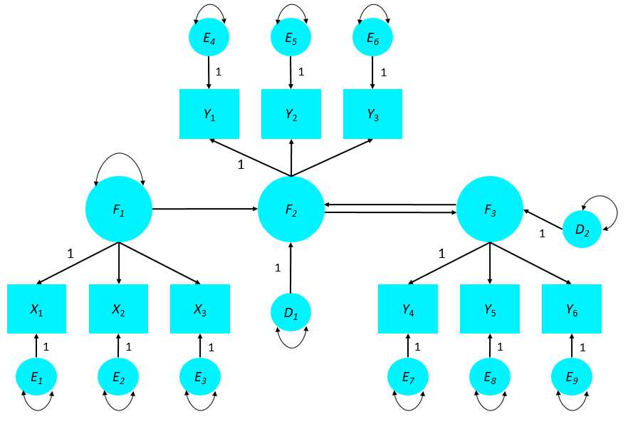

(for the answer, click on “Code”) →

```r
#10.x: 45 variances/covariances - 21 free parameters = 24 df; F2 is a cause of F3 but F3 is also a cause of F2)
```

3. There may be some exceptions to #2. There are three situations in which potential problems with identification can be corrected by including a new variable into the model, called an *instrumental variable*. This variable can help correct for problems with estimation by explaining variability in an exogenous variable. There are three problematic situations that may be able to be resolved by including instrumental variables into a model.
   1. Spuriousness: the exogenous variable both causes the endogenous variable and has an error term correlated with the disturbance of the endogenous variable (presumably because an unmeasured variable causes both the exogenous and endogenous variables).
   2. Reverse causation (aka feedback loop): the endogenous variable may cause the exogenous variable
   3. Measurement error in the predictor: measurement error in an exogenous variable that only has a single indicator/is manifest.

It is worth noting that these situations may occur quite frequently in reality and may be worth modeling. Researchers often make assumptions when creating an SEM model that may be untenable in the real-world, such as assuming that all constructs relevant to a model have been included *in* the model. These assumptions are implicitly made during model specification. For instance, one may hypothesize that self-mutilation (e.g., cutting) (Y) is driven by the experience of shame (X). However, cutting may also *result in* further increases in shame, indicating a feedback loop among these phenomena. If a researcher does not include a causal path from Y to X in their model, they are making the erroneous assumption that shame causes cutting but not the reverse.

Thus, including instrumental variables to ensure model identification may allow a researcher to more accurately depict a real-world process (albeit at the cost of parsimony).

(For more on instrumental variables, see [this page on David Kenny’s website.](http://davidakenny.net/cm/iv.htm))

## 4.2 Empirical underidentification: structural models

As in the case of the measurement component of SEM, the structural component may also incur issues with *empirical identification*. Again, these issues occur not in deciding on the *theoretical/conceptual* model to test but in the actual data being evaluated. For instance, no two variables (manifest or latent) can have a perfect correlation or problems with estimation will ensue.

# 5 Identification of fully latent SEM models

In order to determine the identification status of an SEM both the measurement component and the and structural component must meet their respective requirements for identification outlined above. Note that this is only the case in models in which *all variables included in the structural component are latent, with at least two indicators*. In cases where observed variables are included in the structural component of a model, identification can still be obtained by turning observed variables into single-indicator latent factors with pre-specified error variances (see Kline p. 214-219).

# 6 LISREL all-Y notation

Before we get into the lavaan code behind a full SEM, let’s revisit the notation used for the matrices that go into this analysis. This will come in handy especially when we want to inspect our models for estimation problems or in order to improve model fit. Standard matrix notation used in programs like lavaan derive from the original LISREL program, developed in the 1970s, one of the first widely used SEM programs. Lavaan uses the simpler version of LISREL notation, referred to as *“all-Y” notation*, which ignores the difference between exogenous and endogenous variables in the model, leaving the researcher to distinguish these themself (e.g., via a diagram). For instance, loadings for both exogenous and endogenous variables are included in the lambda matrix.

| Parameter | Matrix | English | Description |
| --- | --- | --- | --- |
| $$\lambda_y$$ | **$$\Lambda_y$$** | lambda-y | loadings for all manifest (measured) variables |
| $$\psi$$ | **$$\Psi$$** | psi | covariance matrix of latent variables, disturbances |
| $$\beta$$ | **$$B$$** | beta | regression paths |
| $$\theta_\epsilon$$ | **$$\Theta_\epsilon$$** | theta-epsilon | measurement errors for all manifest variables |